# FINAL-PROJECT-FINAL slides

## Data Analysis:Regressions and Correlations Between Variables

*Note:* Some of the data is questionable. For example, the GDP growth of Guyana is averaged at 40% and Brunei has a GDPPC higher than both Norway and the United States. When necessary, this data is emphasized as outliers. Otherwise, the data is assumed to be reliable.

Also, each dynamic chart has a png copy beneath it for ease of reading when using the html file.

**Exports and GDP growth:** Illustrating the resource curse for both GDP and GDPPC growth

```python
dffig = compdat.loc[compdat.year==year]\
            .dropna(subset=['NR_TE', 'GDP_grow', 'gdp_pc'])\
            .sort_values(by='region').reset_index()
mod = smf.ols(formula='NR_TE ~ GDP_grow', data=dffig, missing='drop').fit()
mod.summary2()
```

| Model: | OLS | Adj. R-squared: | -0.016 |
| --- | --- | --- | --- |
| Dependent Variable: | NR_TE | AIC: | 462.2619 |
| Date: | 2022-11-26 16:17 | BIC: | 466.0043 |
| No. Observations: | 48 | Log-Likelihood: | -229.13 |
| Df Model: | 1 | F-statistic: | 0.2680 |
| Df Residuals: | 46 | Prob (F-statistic): | 0.607 |
| R-squared: | 0.006 | Scale: | 855.60 |

|  | Coef. | Std.Err. | t | P>\|t\| | [0.025 | 0.975] |
| --- | --- | --- | --- | --- | --- | --- |
| Intercept | 65.2929 | 4.4252 | 14.7548 | 0.0000 | 56.3855 | 74.2004 |
| GDP_grow | -0.2549 | 0.4925 | -0.5176 | 0.6072 | -1.2462 | 0.7364 |

| Omnibus: | 5.823 | Durbin-Watson: | 1.870 |
| --- | --- | --- | --- |
| Prob(Omnibus): | 0.054 | Jarque-Bera (JB): | 4.588 |
| Skew: | -0.640 | Prob(JB): | 0.101 |
| Kurtosis: | 2.190 | Condition No.: | 9 |

```python
dffig2 = oildat.loc[oildat.year==year]\
            .dropna(subset=['NR_TE', 'GDP_grow', 'gdp_pc', 'OR'])\
            .sort_values(by='region').reset_index()
mod = smf.ols(formula='NR_TE ~ GDP_grow', data=dffig2, missing='drop').fit()
mod.summary2()
```

| Model: | OLS | Adj. R-squared: | -0.027 |
| --- | --- | --- | --- |
| Dependent Variable: | NR_TE | AIC: | 298.7369 |
| Date: | 2022-11-26 16:17 | BIC: | 301.6049 |
| No. Observations: | 31 | Log-Likelihood: | -147.37 |
| Df Model: | 1 | F-statistic: | 0.2151 |
| Df Residuals: | 29 | Prob (F-statistic): | 0.646 |
| R-squared: | 0.007 | Scale: | 842.57 |

|  | Coef. | Std.Err. | t | P>\|t\| | [0.025 | 0.975] |
| --- | --- | --- | --- | --- | --- | --- |
| Intercept | 71.7513 | 5.4475 | 13.1715 | 0.0000 | 60.6099 | 82.8926 |
| GDP_grow | -0.2396 | 0.5166 | -0.4638 | 0.6463 | -1.2962 | 0.8170 |

| Omnibus: | 6.282 | Durbin-Watson: | 1.079 |
| --- | --- | --- | --- |
| Prob(Omnibus): | 0.043 | Jarque-Bera (JB): | 5.714 |
| Skew: | -1.050 | Prob(JB): | 0.057 |
| Kurtosis: | 2.895 | Condition No.: | 11 |

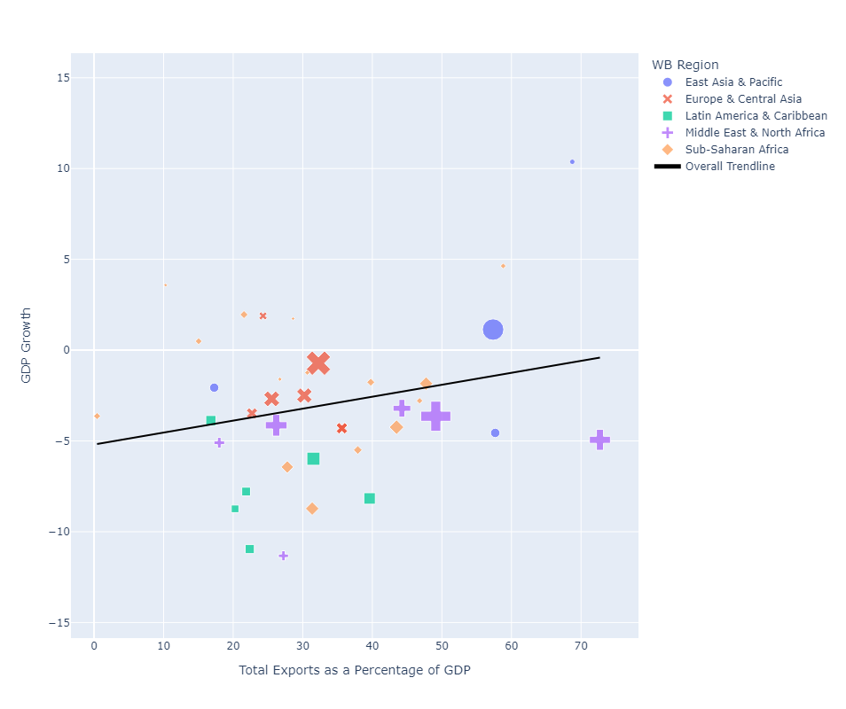

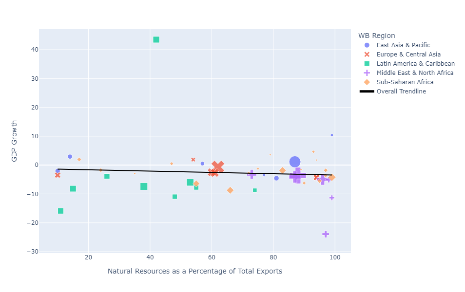

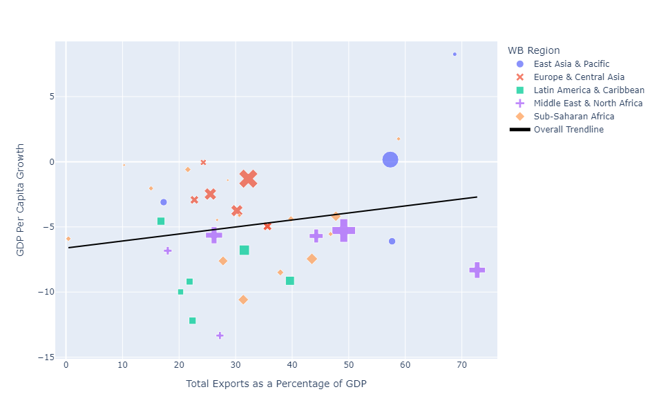

[figure not shown]

#### Analysis:

These two graphs are crucial to demonstrate how natural resources have a negative effect on GDP growth. Fig1 shows how exports are *positively* correlated with GDP; countries with higher export levels also have higher GDP growth. Fig2 demonstrates a unique caveat: natural resources are NOT positively correlated with GDP growth. Fig2 even suggests the opposite, as natural resource exports increase, GDP growth decreases. Even excluding some extreme outliers (like Guyana with GDP growth +43% avg and Libya with GDP growth -23% avg), there is a slight negative correlation between natural resource exports and GDP growth.

GDP per capita shows similar trends. As *total* exports increase, GDP per capita saw a slight increase. However, as natural resources exports increase, GDP per capita growth turns to a slight decrease. The visible differences between fig3 and fig 4 show that nautral resources have a negative effect on GDP growth.

**Prices and GDP Growth:** In this section, we will be focusing on Oil prices and exports. We chose to focus on oil due to more reliable information being available and a consistent international price is available unlike other nautral resources. In addition, the majority of our resource-rich countries export oil.

```python
# Price of Oil from 1998 to 2016
url = 'https://data.worldbank.org/share/widget?indicators=EP.PMP.SGAS.CD'
IFrame(url, width=500, height=300)
```

[interactive chart not shown]

[figure not shown]

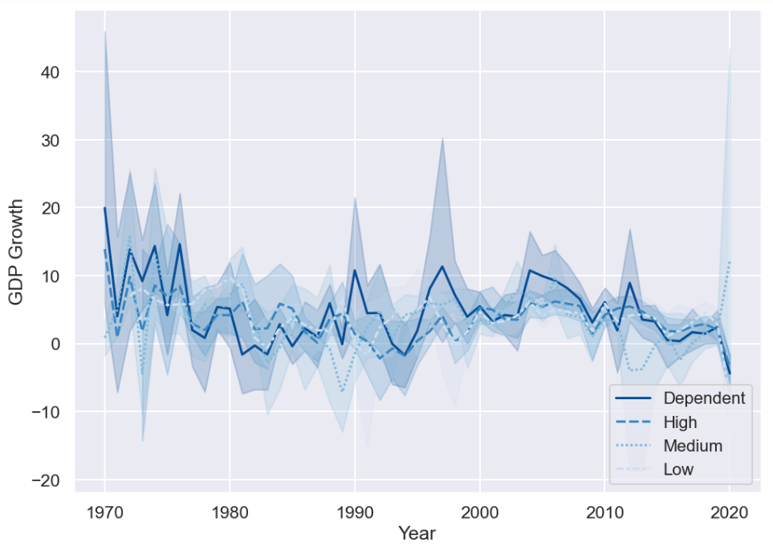

#### Analysis:

This graph demonstrates how different dependencies on oil react to price changes. Two time frames demonstrate these tendendcies best: between 1970 and 1990, and 2000 onward.

**Exports and Government Rents:** Here, we will be establishing a correlation between dependence on nautral resources and government rents. Ultimately, this correlation demonstrates how governments employ resource revenues

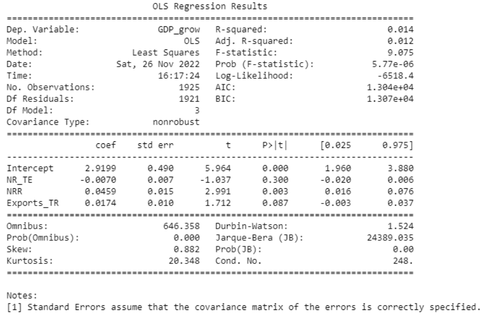

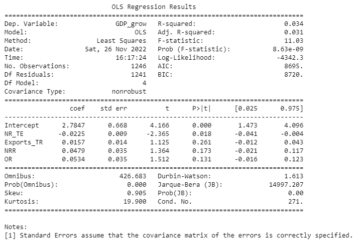

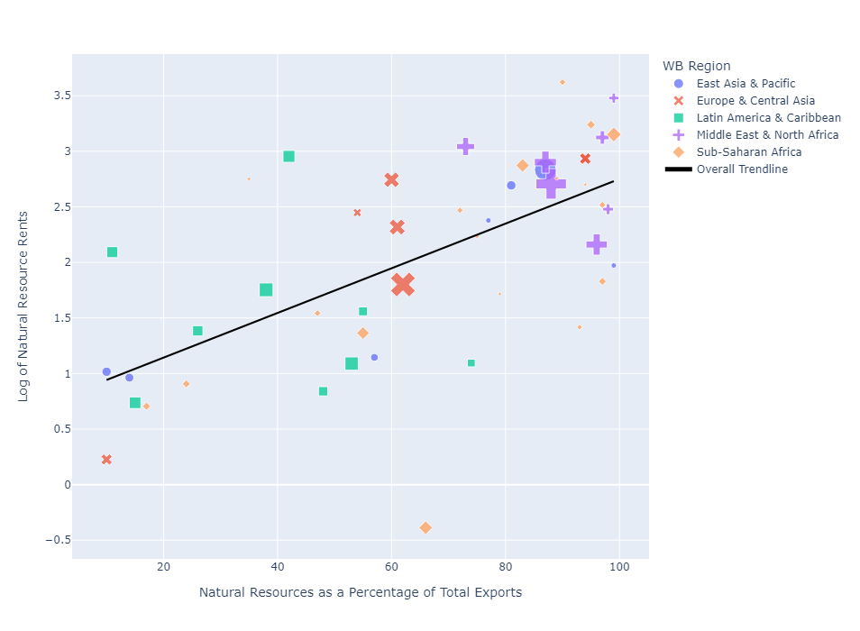

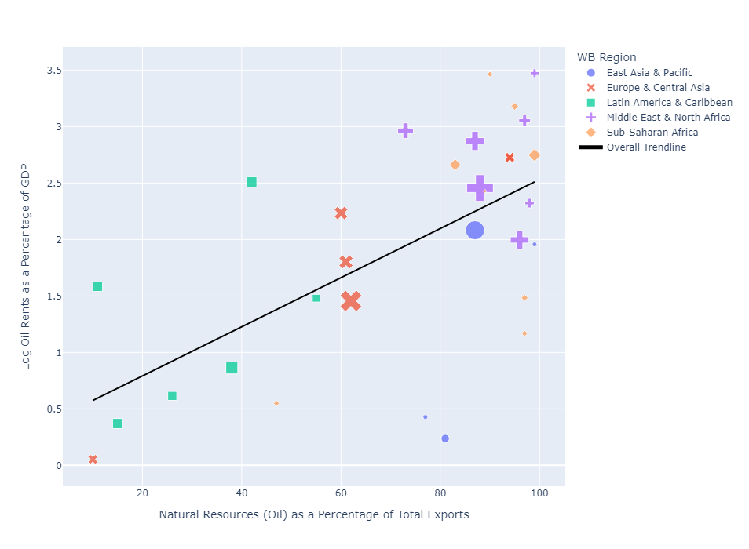

#### Analysis:

It is extrememly important to note the regional differences for both natural resources and oil. The Middle East consistently ranks highest for oil exports and high resource rents. The countries with highest rents also tend to be authoritarian, such as Iraq, Saudi Arabia, and the Democratic Republic of Congo. These nations also have some of the most human rights violations and political instability. The countries with the highest rents also have medium-low GDP per capita, like Iraq and Angola. Clearly, there is a diversion of revenue from the people of the country to the government.

**Over Time:** How GDP growth and resource rents influence economic growth over time

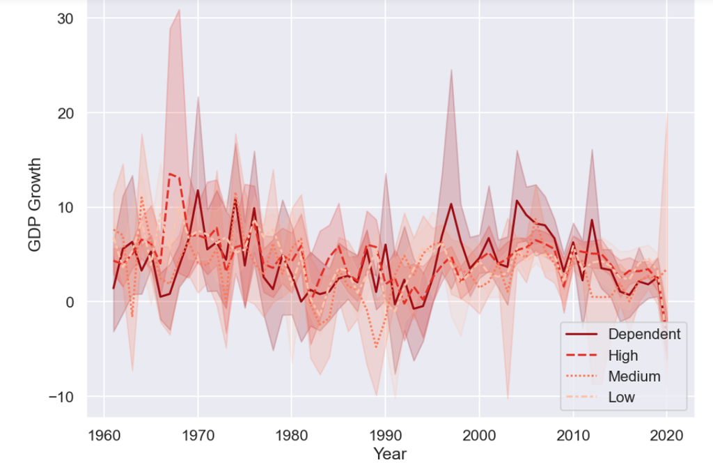

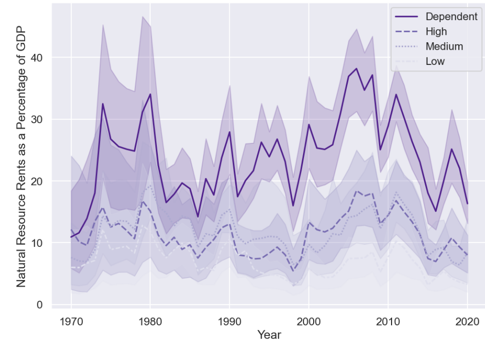

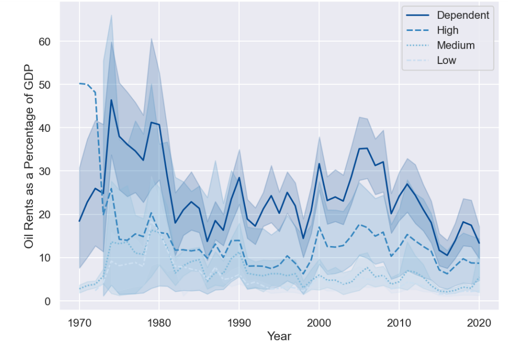

#### Analysis:

As discussed in the price section, higher dependence on nautral resources creates sporatic growth and inconsistent trend lines. This is shown most clearly whe comparing dependence levels over time. Though averages are consistently positive (excluding dips in the 1980s and 2009), the highly dependent countries have much more randomized and erratic growth. An interesting note is that the overall natural resource trends follow the changes in oil prices more than the oil price nations alone. This is likely due to overall market dips when oil prices are low, affecting other natural resource markets.

Changes in rents in the dependent category for both all resources and oil-specific countries most strongly mimic trends in history. The most notable is the 2009 recession, which created a negative trend in GDP growth and rents. Both declined rapidly, but bounced back quickly. However, after 2009, most natural resources increased in price, but GDP growth did not follow this trend. It takes longer for countries to respond to increases in prices than rapid declines. This is likely due to the demand for natural resources being roughly stable *except* for during recessions. Then, as demand returns to normal slowly, resource rich countries have more long-term effects to their supply markets than the demand markets.

Thus, natural resources tend to have negative effects on grow, as negative shocks will be more long-lasting and dramatic than positive shocks. Over time, depedence on these resources will create asymmetrical and erratic growth, limiting true and stable development for underdeveloped countries.

## Conclusion

Observing export centralization, price volatility, and resource rents illustrates that resource endowment *does* correlate heavily with economic stagnaition. Compared to total exports, natural resources have negative effects on GDP growth, GDP per capita growth, and economic diversity. Natural resources also seem to enduce economic instability, as these more resource-dependent countries are less economically stable and have erratic growth.

## Sources

Adams, Dawda, Kweku Adams, Subhan Ullah, and Farid Ullah. “Globalisation, Governance, Accountability and the Natural Resource ‘curse’: Implications for Socio-Economic Growth of Oil-Rich Developing Countries.” *Resources Policy* 61 (2019): 128–40. https://doi.org/10.1016/j.resourpol.2019.02.009.

Federal Reserve Bank of St. Louis. "Historical WTI spot crude oil prices." *Drilling Manual*. https://www.drillingmanual.com/crude-oil-price-history-graph-tables-for-last-80-years/.

Ghura, Dhaneshwar and Catherine Pattillo. “Macroeconomic Policy Frameworks for Resource-Rich Developing Countries.” *International Monetary Fund* (2012): 1-55.

Haseeb, Muhammad, Sebastian Kot, Hafezali Iqbal Hussain, and Fakarudin Kamarudin. “The Natural Resources Curse-Economic Growth Hypotheses: Quantile–on–Quantile Evidence from Top Asian Economies.” *Journal of Cleaner Production* 279 (2021): 123596–. https://doi.org/10.1016/j.jclepro.2020.123596.

Lederman, Daniel, William F. Maloney. *Natural Resources Neither Curse nor Destiny.* Palo Alto, CA: Stanford Economics and Finance, an imprint of Stanford University Press, 2007.

Murshed, Syed Mansoob, and Leandro Antonio Serino. “The Pattern of Specialization and Economic Growth: The Resource Curse Hypothesis Revisited.” *Structural Change and Economic Dynamics* 22, no. 2 (2011): 151–61. https://doi.org/10.1016/j.strueco.2010.12.004.

Ross, Michael Lewin. *The Oil Curse : How Petroleum Wealth Shapes the Development of Nations.* Princeton, N.J: Princeton University Press, 2012.

Shu Yang, Elyas Abdulahi, Muhammad Afaq Haider, and Muhammed Asif Khan. “Revisiting the Curse: Resource Rent and Economic Growth of Sub-Sahara African Countries.” *International Journal of Economics and Financial Issues* 9, no. 1 (2019): 121–30.

Venables, Anthony. “Using Natural Resources for Development: Why Has It Proven So Difficult?” *Journal of Economic Perspectives*, 30 no.1 (2016): 161-184. https://www.aeaweb.org/articles?id=10.1257/jep.30.1.161.

Wang, Rong, Junlan Tan, and Shuangliang Yao. “Are Natural Resources a Blessing or a Curse for Economic Development? The Importance of Energy Innovations.” *Resources Policy* 72 (2021): 102042–. https://doi.org/10.1016/j.resourpol.2021.102042.

Williams, Andrew. “Shining a Light on the Resource Curse: An Empirical Analysis of the Relationship Between Natural Resources, Transparency, and Economic Growth.” *World Development* 39, no. 4 (2011): 490–505. https://doi.org/10.1016/j.worlddev.2010.08.015.

### Sources for Data

[Venables - Appendix Data](https://assets.aeaweb.org/asset-server/articles-attachments/jep/app/3001/30010161_app.pdf)  
[World Bank - GDP growth Data](https://data.worldbank.org/indicator/NY.GDP.MKTP.KD.ZG)  
[World Bank - GDP per capita Data](https://data.worldbank.org/indicator/NY.GDP.PCAP.KD.ZG)  
[World Bank - Oil Rents as % of GDP](https://data.worldbank.org/indicator/NY.GDP.PETR.RT.ZS)  
[World Bank - Total Exports as % of GDP](https://data.worldbank.org/indicator/NE.EXP.GNFS.ZS)  
[World Bank - Total Natural Resources Rents as % of GDP](https://data.worldbank.org/indicator/NY.GDP.TOTL.RT.ZS)  
[OEC - Export information](https://oec.world/en/profile/country/lbr)